# sf25 | STAT 425 Midterm

Steven Feng

10/14/2021

Steven Feng

*I pledge my honor that I have not violated the honor code during this exam and have followed all instructions.*

*Signed 10/14/2021 7:20pm CT.*

# Set up and packages

```r
set.seed(425)

#install.packages("knitr")

library(knitr)
```

# Problem 1 [Trials for VBG Combination Therapy]:

## Part a)

The first stage data measures the response rate of VBG therapy among a fixed group of patients $(n = 39)$. As such, I believe an appropriate model for these data is a binomial model, specifically $\textbf{Y} \sim Bin(39, \theta)$; we’ll take $\theta$ to capture the response rate, and in the Bayesian framework $\theta$ is randomly distributed. Its likelihood is proportional to $\theta^{n}(1-\theta)^{39-n}$ with $n$ denoting the number of successful responses, in this case $19$.

## Part b)

The conjugate prior for the binomial model is the beta distribution, specifically, $\theta \sim Beta(\alpha, \beta).$ We can use the facts of the study investigators to try to choose reasonable values for the hyper-parameters:

- I will interpret 90% confidence of $\theta > 0.25$ to mean that $Pr(\theta > 0.25) = 0.9$.
- I will take the mode of $0.4$ to be the mean of $\theta, \implies \dfrac{\alpha}{\alpha + \beta} = 0.4 \implies \beta = \dfrac{\alpha}{0.4} - \alpha$.
- I will use some rote guess-and-check to find a good enough result and simulate from the distribution to check my work.

```r
## Commence guess-and-check
pbeta(0.25, 3, (3/0.4 - 3), lower.tail = FALSE)
```

```
## [1] 0.7942178
```

```r
pbeta(0.25, 6, (6/0.4 - 6), lower.tail = FALSE)
```

```
## [1] 0.888331
```

```r
pbeta(0.25, 7, (7/0.4 - 7), lower.tail = FALSE)
```

```
## [1] 0.9072456
```

```r
pbeta(0.25, 6.5, (6.5/0.4 - 6.5), lower.tail = FALSE)
```

```
## [1] 0.8983037
```

```r
pbeta(0.25, 6.6, (6.6/0.4 - 6.6), lower.tail = FALSE)
```

```
## [1] 0.90017
```

This leads me to think an appropriate hyper-parameterization to be $\theta \sim Beta(6.6, 9.9).$ We can verify this result with MC simulation:

```r
## Simulate many theta
theta_q1.2 <- rbeta(1e5, 6.6, 9.9)
mean(theta_q1.2)
```

```
## [1] 0.4002054
```

```r
median(theta_q1.2)
```

```
## [1] 0.3962156
```

```r
mean(theta_q1.2 > 0.25)
```

```
## [1] 0.90083
```

## Part c)

A result (which may be trivial in this point in class) is that the posterior distribution of a Beta-distributed binomial parameter $\theta \sim Beta(\alpha, \beta)$ is $\theta|\textbf{Y} \sim Beta(\alpha + y, n - y + \beta).$ In our trial:

$$\alpha = 6.6, \beta = 9.9, y = 19, n = 39 \implies \theta|\textbf{Y} \sim Beta(25.6, 29.9) \implies E[\theta|\textbf{Y}] = \dfrac{25.6}{25.6 + 29.9} = 0.4613.$$
We can use the $\texttt{quantile()}$ function in R to find the 95% credible interval:

```r
#Simulate from posterior distribtion
theta_post_q1.3 <- rbeta(1e5, 25.6, 29.9)
quantile(theta_post_q1.3, c(0.025, 0.975))
```

```
##      2.5%     97.5%
## 0.3329498 0.5919623
```

## Part d)

The clinical trial for combination therapy stops for futility if the probability of a response rate after the first stage smaller than $0.4$ is greater than $0.9$. In other words this is the posterior probability $P(\theta < 0.4|\textbf{Y})$ and we would like to see whether it is over-or-under $0.9$.

### Solve analytically

```r
pbeta(0.4, 25.6, 29.9, lower.tail = TRUE)
```

```
## [1] 0.1803949
```

### Solve with MC Simulation

```r
mean(theta_post_q1.3 < 0.4)
```

```
## [1] 0.18101
```

The probability of a response rate at the end of the first stage is less than $0.9$, I do not believe the trial should be stopped at the interim analysis.

## Part e)

To summarize premise of the problem:

- A trial is stopped for toxicity if the probability that the rate of serious adverse events is greater than 10% is greater than 90%.
- The rate of serious events should be around 5% a priori.
- There is a 90% chance that the rate of serious events is less than 8% a priori.
- In the first stage of the study, $3$ of $39$ patients recorded a serious event.

We can again solve this problem with a similar Bayesian analysis. We can take the number of serious events out of a group of patients as another binomial model,

$$\textbf{S} \sim Bin(39, \theta_S)$$
this time, a priori. $\theta_S \sim Beta(\alpha_S, \beta_S); n_S = 39, y_S = 3.$

Applying similar reasoning as 1b), I will set the mean of $\theta_S$ as $0.05 \implies \dfrac{\alpha}{\alpha + \beta} = 0.05 \implies \beta = \dfrac{\alpha}{0.05} - \alpha.$ I will also claim that $Pr(\theta_S < 0.08) = 0.9$.

Using the same unfortunate guess-and-check-and-check method from earlier:

```r
pbeta(0.08, 4, (4/0.05 - 4), lower.tail = TRUE)
```

```
## [1] 0.8854055
```

```r
pbeta(0.08, 5, (5/0.05 - 5), lower.tail = TRUE)
```

```
## [1] 0.9051864
```

```r
pbeta(0.08, 4.5, (4.5/0.05 - 4.5), lower.tail = TRUE)
```

```
## [1] 0.8958309
```

```r
pbeta(0.08, 4.75, (4.75/0.05 - 4.75), lower.tail = TRUE)
```

```
## [1] 0.9006341
```

```r
pbeta(0.08, 4.716, (4.716/0.05 - 4.716), lower.tail = TRUE)
```

```
## [1] 0.8999959
```

We can start off by saying that $\theta_S \sim Beta(4.716, 89.604)$ and verify with MC methods:

```r
theta_q1.5 <- rbeta(1e5, 4.716, 89.604)
mean(theta_q1.5)
```

```
## [1] 0.05008211
```

```r
median(theta_q1.5)
```

```
## [1] 0.04693997
```

```r
mean(theta_q1.5 < 0.08)
```

```
## [1] 0.89856
```

The posterior distribution $\theta_S|\textbf{S} \sim Beta(4.716 + 3, 89.604+39-3) = Beta(7.716, 125.604)$. The a posteriori probability that the rate of serious events greater than $0.1$ is $Pr(\theta_S > 0.1|\textbf{S})$ and we need to check it against $0.9$.

### Solve analytically

```r
pbeta(0.1, 7.716, 125.604, lower.tail = FALSE)
```

```
## [1] 0.03229738
```

### Solve with MC Simulation

```r
## Sample from posterior distribution
theta_post_q1.5 <- rbeta(1e5, 7.716, 125.604)
mean(theta_post_q1.5 > 0.1)
```

```
## [1] 0.0321
```

The probability that the rate of adverse events is greater than $0.1$ given the first stage data is around 3% either way. Because it is less than a 90% chance, I would not stop the trial for toxicity.

## Part f)

We can repeatedly simulate $100$ values from the posterior predictive distribution of $\textbf{S}$ and see how many of these simulations turn fewer than $10$ serious events.

More algorithmically:

1. Sample $m_{MC}$ values from the posterior distribution of $\theta_S|\textbf{S} \sim Beta(7.716, 125.604).$
2. For each Beta instance $\texttt{i:}$
   - Sample $n_{MC}$ binomial instances with trial size $100$ and success probability $\texttt{i}$.
3. Determine the frequentist probability that a given posterior predictive binomial sample contains fewer than $10$ serious events.

Let $n_{MC} = m_{MC} = 10^5$. We already have a sample from the posterior distribution from above, named $\texttt{theta_post_q1.5}$.

```r
pp_samples <- rbinom(1e5, 100, theta_post_q1.5)
mean(pp_samples < 10)
```

```
## [1] 0.88068
```

I would tell Dr. Vannucci that the probability of having fewer than $10$ patients with serious events if $100$ additional patients enroll is approximately 88%. This seems promising, but it does not hit the well-used 90% threshold; in that case, I will tell Dr. Vannucci that it might not be safe to continue on with the faces of the trial given the current VBG formulation. $\blacksquare$

# Problem 2 [Plane Crashes, 1976 - 1985]:

## Part a)

If we are given that the fatal accidents in a year is distributed under $Pois(\lambda)$ then an intuitive first choice for a prior distribution is some sort of Gamma, i.e., $\lambda \sim Gam(\alpha, \beta)$.

### Jeffreys prior

I don’t want to do any inferential gymnastics to guess a rate a priori (or perhaps I am just lazy) so Jeffreys prior seems like a good place to start. As we have derived in class, the Jeffreys prior for a Poisson model is $\lambda \sim \lim_{\beta\to0}Gam(0.5, \beta)$ and as such the posterior distribution $\lambda|\textbf{y} \sim Gam(\alpha + \sum y_i, \beta + n); \sum y_i = 238, n = 10 \implies \lambda|\textbf{y} \sim Gam(238.5, 10).$

Lucky for us, the Poisson-Gamma conjugate model’s predictive posterior distribution exists in closed form as $z|\textbf{y} \sim NB(238.5, 10).$ We can use the posterior predictive distribution and $\texttt{qnbinom()}$ to calculate the 95% predictive interval:

```r
qnbinom(c(0.025, 0.975), size = 238.5, mu = 23.85, lower.tail = TRUE)
```

```
## [1] 14 34
```

If we did not have the posterior predictive distribution in closed form, we could simulate a large number of $\lambda$s from the posterior distribution and draw an equally large amount of Poisson variables with our posterior parameters, then compute quantiles via MC estimates:

```r
lambda_post_q2.1 <- rgamma(1e5, 238.5, 10)
pp_samples_q2.1 <- rpois(1e5, lambda_post_q2.1)
quantile(pp_samples_q2.1, c(0.025, 0.975))
```

```
##  2.5% 97.5%
##    14    34
```

There is a 95% chance that the number of worldwide fatal accidents in 1986 is within the interval $[14, 34]$ (with a posterior expected number of fatal accidents of $23.85$).

## Part b)

In this problem we have $10$ data points $y_1, \cdots, y_{10}$ each following an independent Poisson distribution $y_i \sim Pois(x_i\lambda), i \in [1,10]$ with $\lambda$ being the rate of fatal accidents (a random variable constant throughout distributions) and $x_i$ being an explanatory variable proportional to the number of passenger miles flown in the year $1975 + i$.

Because the data does not include it we should estimate the number of passenger miles flown for each year in the dataset. Let’s impute some data:

```r
## Input data of question 2
fatalities <- data.frame(
  "Year" = 1976:1985,
  "Accidents" = c(24, 25, 31, 31, 22, 21, 26, 20, 16, 22),
  "Deaths" = c(734, 516, 754, 877, 814, 362, 764, 809, 223, 1066),
  "Death.Rate" = c(0.19, 0.12, 0.15, 0.16, 0.14, 0.06, 0.13, 0.13, 0.03, 0.15)
  )

## Estimate the miles flown that year; ~= deaths * 1e8 / death rate
miles <- fatalities$`Deaths` * 1e8 / fatalities$`Death.Rate`
fatalities$`Miles` <- miles / 1e12
```

### Jeffreys prior

We repeat the analysis in 2a) and get $\lambda|\textbf{y} \sim Gam(238.5, 10)$. This time, however, we need to scale the posterior draws of $\lambda$ by the $.8$ trillion miles flown in $1986$.

```r
lambda_post_q2.2 <- rgamma(1e5, 238.5, 10)
pp_samples_q2.2 <- rpois(1e5, .8 * lambda_post_q2.2)
quantile(pp_samples_q2.2, c(0.025, 0.975))
```

```
##  2.5% 97.5%
##    11    29
```

```r
mean(pp_samples_q2.2)
```

```
## [1] 19.0943
```

## Part c)

I would suggest that it is more reasonable to assume that each year follows its own Poisson distribution, because the assumption that the fatal accidents are distributed i.i.d from a common distribution does not seem fair to me.

We can intuitively reason this by extrapolating these results into the future. As I write this in the year 2021, it does not seem fair that airplane fatalities every year come from a common distribution. If any given year records fewer than $14$ fatalities or more than $34$, then the number of fatalities lies outside the 95% CI, and having more than $34$ crashes can be reasonable the more people fly in airplanes.

We can also verify this with results. Let’s simulate new observations for the year 1985, where $0.7110$ trillion miles were flown.

```r
lambda_post_1985_q2 <- rgamma(1e5, 238.5, 10)
pp_samples_1985_q2.1 <- rpois(1e5, lambda_post_1985_q2)
pp_samples_1985_q2.2 <- rpois(1e5, 0.7110* lambda_post_1985_q2)

## Method 1 with one common distribution
quantile(pp_samples_1985_q2.1, c(0.025, 0.975))
```

```
##  2.5% 97.5%
##    14    34
```

```r
mean(pp_samples_1985_q2.1)
```

```
## [1] 23.85521
```

```r
## Method 2 with 10 individual distributions
quantile(pp_samples_1985_q2.2, c(0.025, 0.975))
```

```
##  2.5% 97.5%
##     9    26
```

```r
mean(pp_samples_1985_q2.2)
```

```
## [1] 16.95573
```

Method 1 will suggest the same CI no matter what the data on miles flown. Even if a direct scaling is not accurate (as above) Method 2 with the $n = 10$ individual distributions can capture the truth of 1985 much better with the proper scale on the explanatory variable.

Also, in terms of loose sensitivity analysis, changing prior specifications for $\lambda$ can wildly change inference for Method 1, but in Method 2 changes in prior specification can be observed the explanatory variable. $\blacksquare$

# Problem 3 [Conjugate Analyses]:

# Problem 4 [Bayes Factor and Model Selection]:

## Part b)

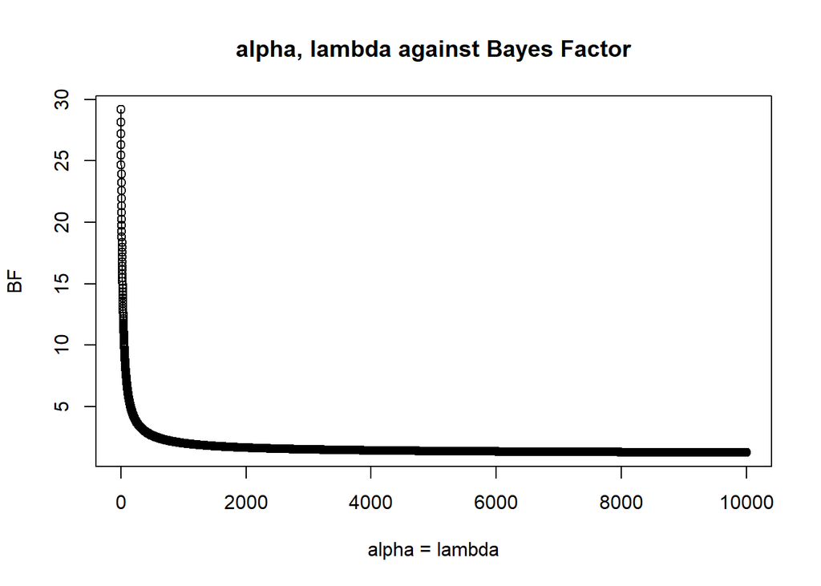

```r
solve_bf_q3.2 <- function(hyperparam) {
  numerator <- pbeta(0.5, hyperparam + 49, hyperparam + 69)
  return(numerator / (1 - numerator))
}
plot_q3.2 <- function(hyperparams) {
  yvals <- sapply(hyperparams, solve_bf_q3.2)
  plot(hyperparams, yvals, main = "alpha, lambda against Bayes Factor", xlab = "alpha = lambda", ylab = "BF")
  lines(hyperparams, yvals)
}

max_q3.2 <- 10000
plot_q3.2(seq(1, max_q3.2, by = 1))
```

```r
solve_bf_q3.2(1e15)
```

```
## [1] 1.000001
```

If we let the hyperparameter specification get large enough, i.e. a very opinionated hyperparamater, the likelihood is washed out and we converge onto the BF of $1$ As priors become more opinionated, we are less convinced that $M1$ represents the truth any more than $M2$ does. $\blacksquare$

# Problem 5 [National Exam Scores in Public Schools]:

We are given that:

$$y_1 \sim N(\theta_1, \dfrac{14}{8})$$
$$y_2 \sim N(\theta_2, \dfrac{14}{24})$$

and would like to conduct some inference regarding parameters $\theta_1, \theta_2$.

## Part a)

Let us assume a prior variance $\sigma^2_0 = 16.$

### Conjugate prior

For the case of conjugate analysis on a normal mean with a known model variance, we can set a conjugate prior to be $\theta_i \sim N(\bar{y}_{i},16)$ in which case

$$\theta_1 \sim N(40,16)$$
and
$$\theta_2 \sim N(26,16).$$

From **Lecture 7 slides**, $\theta_i|\textbf{x} \sim N(\mu_{i,n}, \sigma^2_{i,n});$

$$\dfrac{1}{\sigma^2_{i,n}} = \dfrac{1}{\sigma^2_{i,0}} + \dfrac{n_i}{\sigma^2}$$
$$\mu_{i,n} = \sigma^2_{i,n}(\dfrac{\mu_{i,0}}{\sigma^2_{i,0}} + \dfrac{\sum\textbf{x}_i}{\sigma^2})$$
and so we can summarize all of our parameters here after hand calculation:

| School | Scores.Sum | Model.Var | Prior.Mean | Prior.Variance | Posterior.Mean | Posterior.Var |
| --- | --- | --- | --- | --- | --- | --- |
| 1 | 320 | 14 | 40 | 16 | 40 | 1.5775 |
| 2 | 624 | 14 | 26 | 16 | 26 | 0.5628 |

With the one assumption being that the data variance can be approximated with the given $\sigma^2 = 14$ as $\sum x_i^2$ is not given nor is the whole data vector.

In conclusion,

$$\theta_1|\textbf{x}_1 \sim N(40,1.5775)$$
$$\theta_2|\textbf{x}_2 \sim N(26,0.5628)$$
.

Estimates for $\theta_1$ and $\theta_2$ a posteriori are, according to expected values, $40$ and $26$ respectively. Their 95% credible intervals are as follows:

### Exact approach

```r
qnorm(c(0.025, 0.975), 40, sqrt(1.5775))
```

```
## [1] 37.53831 42.46169
```

```r
qnorm(c(0.025, 0.975), 26, sqrt(0.5628))
```

```
## [1] 24.52964 27.47036
```

There is a 95% chance that $\theta_1$ lands in the interval $[37.5383, 42.4617]$ and $\theta_2 \in [24.5296, 27.4704].$ Note that the CI for School 1 exists entirely above the CI for School 2.

### Monte Carlo simulation

```r
quantile(rnorm(1e5, 40, sqrt(1.5775)), c(0.025, 0.975))
```

```
##     2.5%    97.5%
## 37.54856 42.47862
```

```r
quantile(rnorm(1e5, 26, sqrt(0.5628)), c(0.025, 0.975))
```

```
##     2.5%    97.5%
## 24.53211 27.47447
```

Consistent with our above results.

## Part b)

### Exact approach

Note that the difference of two normal random variables is also a normal random variable with a difference in means and an addition in variances (can be proved using techniques like convolution we acquired in STAT 418). So the analytical form of $\theta_1 - \theta_2 \sim N(14, 2.1403)$.

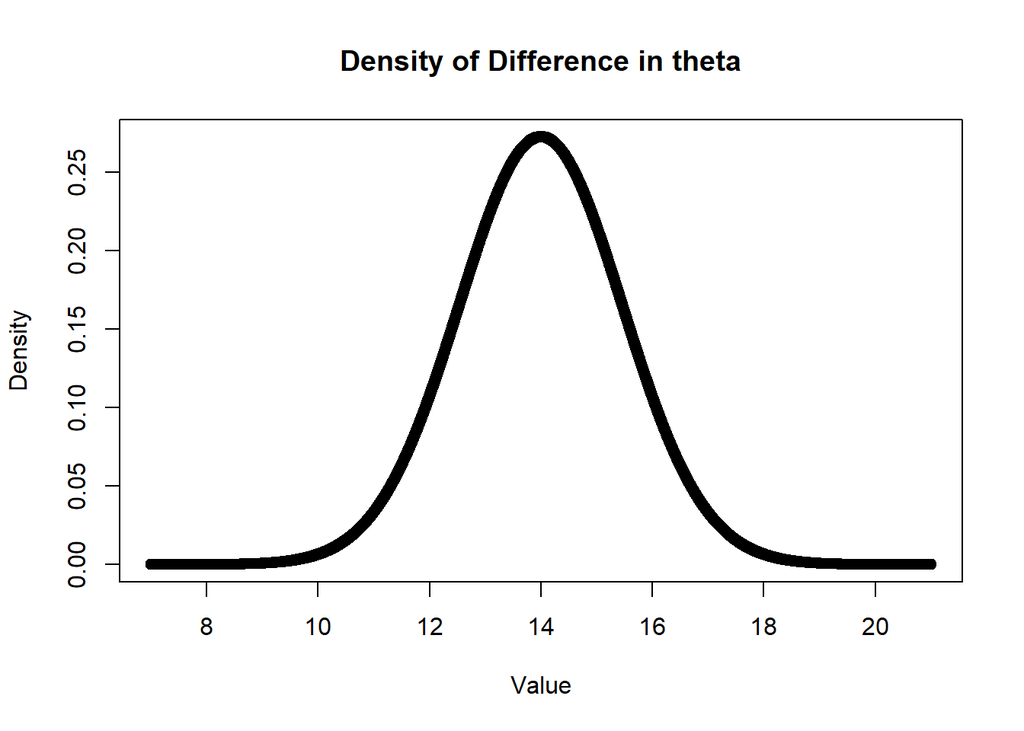

```r
xax_q5.2 <- seq(7, 21, by = 1e-3)
plot(xax_q5.2, dnorm(xax_q5.2, 14, sqrt(2.1403)), main = "Density of Difference in theta", xlab = "Value", ylab = "Density")
```

### Monte Carlo simulation

Of course, when analytical methods fail (or we are too lazy to convolve) we can always turn to MC approximations.

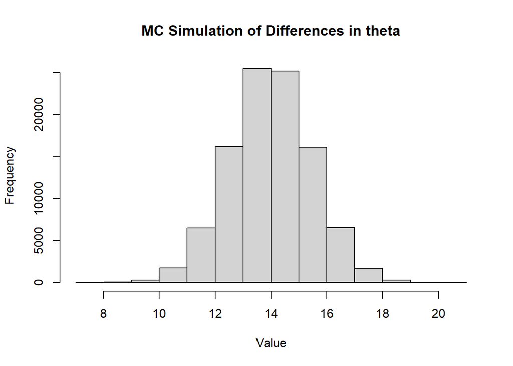

```r
## Simulate from theta1  and theta2 posterior
theta1_post_q5.2 <- rnorm(1e5, 40,  sqrt(1.5775))
theta2_post_q5.2 <- rnorm(1e5, 26,  sqrt(0.5628))

## Simulate their difference
diff_q5.2 <- theta1_post_q5.2 - theta2_post_q5.2

## Plot a histogram of the differences
hist(diff_q5.2, main = "MC Simulation of Differences in theta", xlab = "Value", ylab = "Frequency")
```

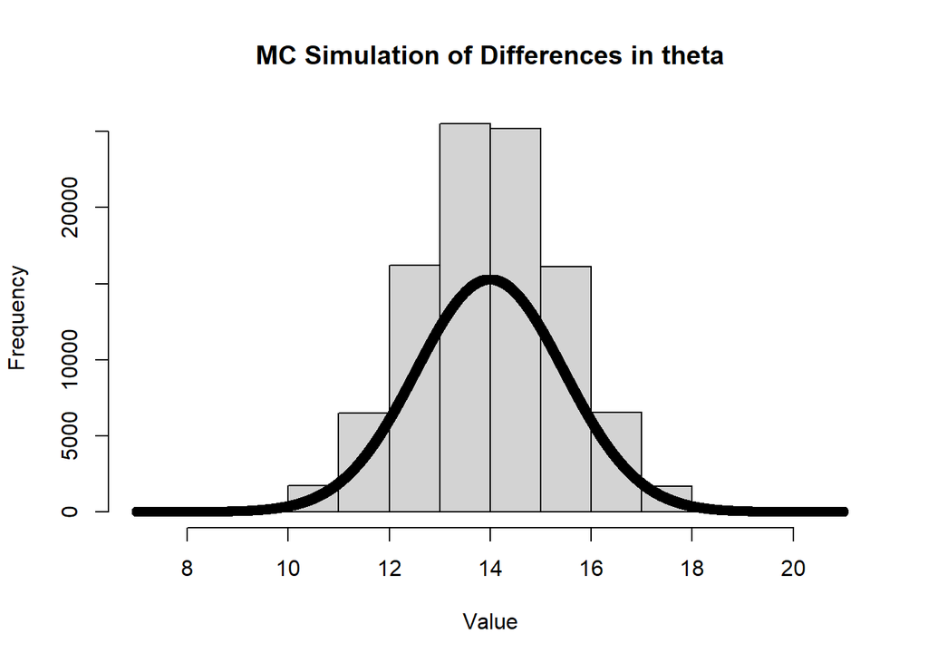

```r
## Overlay the density on top
plot.new()
hist(diff_q5.2, main = "MC Simulation of Differences in theta", xlab = "Value", ylab = "Frequency")
points(xax_q5.2, 14000 * 4 * dnorm(xax_q5.2, 14, sqrt(2.1403)))
```

This has us believe that School 1 scores higher on average than School 2. We can claim that the margin is by $14$ point-units approximately and that the difference has a 95% chance of falling within the range $[11.1326, 16.8674]$.

```r
qnorm(c(0.025, 0.975), 14, sqrt(2.1403))
```

```
## [1] 11.13262 16.86738
```

The posterior probability that School 1 scores better is meaninglessly close to $1$:

```r
pnorm(0, 14, sqrt(2.1403), lower.tail = FALSE)
```

```
## [1] 1
```

A Bayes Factor analysis can help, but I am sorely unconvinced based on this analysis that any model that has School 2 performing better will be favored. It is worth noting that the sample size of School 1 is a third of that of school 2, though.

## Part c)

Let’s try this same analysis for all prior variances $\in [0.16, 1.6, 16, 160, 1.6 \times10^3]$.

```r
question5_sa <- function(data_sums = c(320, 624), data_length = c(8, 24), data_var = c(14, 14), prior_mean = c(40, 26), var) {
  ### The only explicit parameter is prior_var, which is the prior variance according
  ### to the sensitivity analysis; both school districts will have equal prior variance
  ### The output is a dataframe summarizing posterior mean, 95% credible interval, as
  ### well as analysis on the posterior difference

  dataf <- data.frame("School" = c(1,2))

  ##Calculate posterior variances
  pos_var <- 1 / ((1 / var) + (data_length / data_var))
  dataf$`Posterior.Variance` <- pos_var

  ##Calculate posterior means
  pos_mean <- pos_var * ((prior_mean/var) + (data_sums/data_var))
  dataf$`Posterior.Mean` <- pos_mean

  ##Calcualte 95% credible interval
  pos_lb <- qnorm(0.025, pos_mean, sqrt(pos_var))
  dataf$`95%CI.LB` <- pos_lb

  pos_ub <- qnorm(0.975, pos_mean, sqrt(pos_var))
  dataf$`95%CI.uB` <- pos_ub

  ##Calculate the 95% credible interval of the difference
  pos_diff_lb <- qnorm(0.025, pos_mean[1] - pos_mean[2], sum(sqrt(pos_var)))
  pos_diff_ub <- qnorm(0.975, pos_mean[1] - pos_mean[2], sum(sqrt(pos_var)))
  dataf$`95%CI.diff.lB` <- pos_diff_lb
  dataf$`95%CI.diff.uB` <- pos_diff_ub

  return((dataf))
}

for(i in c(0.16, 1.6, 16, 160, 1.6e3)){
  cat("Prior Variance:", i, "\n")
  print(knitr::kable(question5_sa(var = i)))
  cat("\n")
}
```

```
## Prior Variance: 0.16
##
##
## | School| Posterior.Variance| Posterior.Mean| 95%CI.LB| 95%CI.uB| 95%CI.diff.lB| 95%CI.diff.uB|
## |------:|------------------:|--------------:|--------:|--------:|-------------:|-------------:|
## |      1|          0.1465969|             40| 39.24957| 40.75043|      12.55507|      15.44493|
## |      2|          0.1255605|             26| 25.30550| 26.69450|      12.55507|      15.44493|
##
## Prior Variance: 1.6
##
##
## | School| Posterior.Variance| Posterior.Mean| 95%CI.LB| 95%CI.uB| 95%CI.diff.lB| 95%CI.diff.uB|
## |------:|------------------:|--------------:|--------:|--------:|-------------:|-------------:|
## |      1|          0.8358209|             40| 38.20814| 41.79186|      10.92667|      17.07333|
## |      2|          0.4274809|             26| 24.71854| 27.28146|      10.92667|      17.07333|
##
## Prior Variance: 16
##
##
## | School| Posterior.Variance| Posterior.Mean| 95%CI.LB| 95%CI.uB| 95%CI.diff.lB| 95%CI.diff.uB|
## |------:|------------------:|--------------:|--------:|--------:|-------------:|-------------:|
## |      1|          1.5774648|             40| 37.53834| 42.46166|      10.06796|      17.93204|
## |      2|          0.5628141|             26| 24.52962| 27.47038|      10.06796|      17.93204|
##
## Prior Variance: 160
##
##
## | School| Posterior.Variance| Posterior.Mean| 95%CI.LB| 95%CI.uB| 95%CI.diff.lB| 95%CI.diff.uB|
## |------:|------------------:|--------------:|--------:|--------:|-------------:|-------------:|
## |      1|          1.7310665|             40| 37.42128| 42.57872|       9.92705|      18.07295|
## |      2|          0.5812143|             26| 24.50577| 27.49423|       9.92705|      18.07295|
##
## Prior Variance: 1600
##
##
## | School| Posterior.Variance| Posterior.Mean| 95%CI.LB| 95%CI.uB| 95%CI.diff.lB| 95%CI.diff.uB|
## |------:|------------------:|--------------:|--------:|--------:|-------------:|-------------:|
## |      1|          1.7480880|             40| 37.40863| 42.59137|      9.911954|      18.08805|
## |      2|          0.5831207|             26| 24.50333| 27.49667|      9.911954|      18.08805|
```

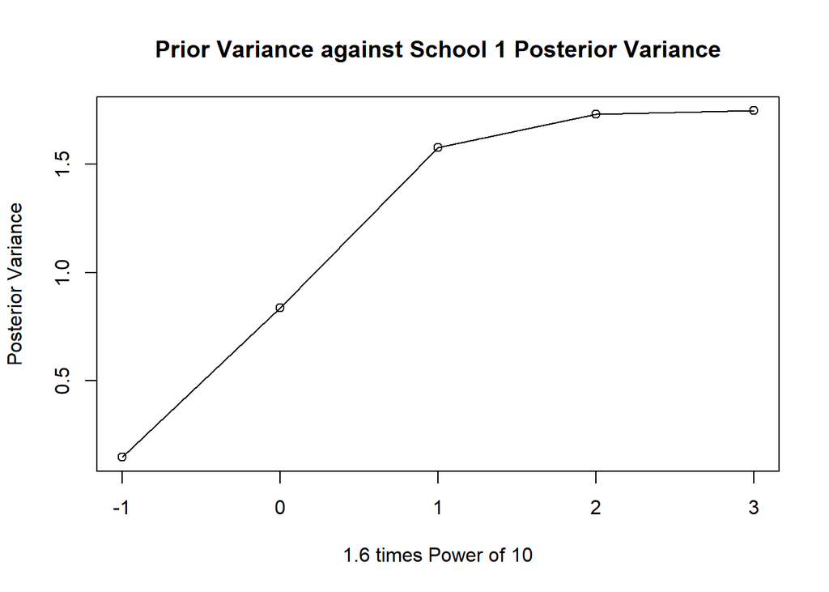

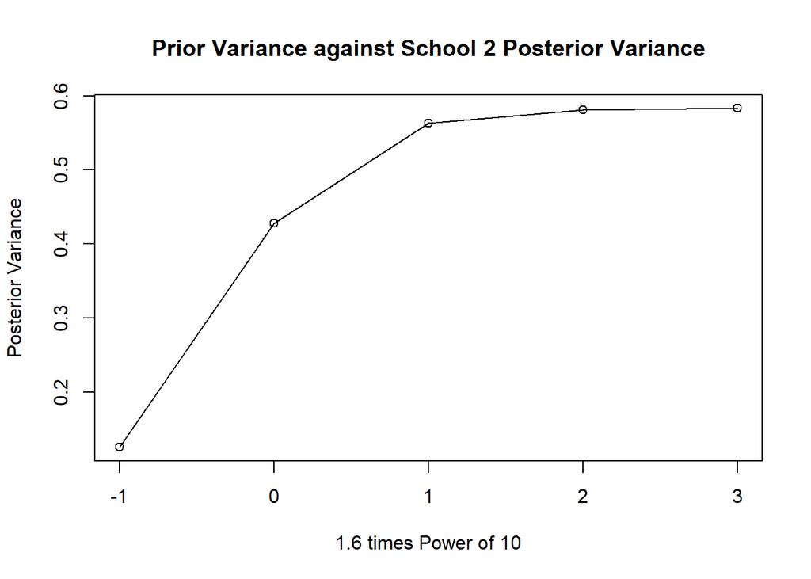

[output not shown]

$$\blacksquare$$